# Tarea 1: Román Vélez

```r
library(tidyverse)
library(rcompanion)
```

# Tarea 1.1: Ejercicio de Propinas

Read data

```r
df_tips <- read_csv("data/tips.csv")
# look data
glimpse(df_tips)
```

```
## Rows: 244
## Columns: 7
## $ total_bill <dbl> 16.99, 10.34, 21.01, 23.68, 24.59, 25.29, 8.77, 26.88, 15.0…
## $ tip        <dbl> 1.01, 1.66, 3.50, 3.31, 3.61, 4.71, 2.00, 3.12, 1.96, 3.23,…
## $ sex        <chr> "Female", "Male", "Male", "Male", "Female", "Male", "Male",…
## $ smoker     <chr> "No", "No", "No", "No", "No", "No", "No", "No", "No", "No",…
## $ day        <chr> "Sun", "Sun", "Sun", "Sun", "Sun", "Sun", "Sun", "Sun", "Su…
## $ time       <chr> "Dinner", "Dinner", "Dinner", "Dinner", "Dinner", "Dinner",…
## $ size       <dbl> 2, 3, 3, 2, 4, 4, 2, 4, 2, 2, 2, 4, 2, 4, 2, 2, 3, 3, 3, 3,…
```

Change some factors

```r
df_tips$day |> unique()
```

```
## [1] "Sun"  "Sat"  "Thur" "Fri"
```

Wrangle data

```r
df_tips <- df_tips %>%
  mutate(day  = fct_relevel(day, c("Thur", "Fri", "Sat", "Sun")))
```

## Q1.1: Get percentiles of the tips with min and max

Get the deciles of the tips variable 2. Get range (max & min)

```r
tibble(tip = df_tips$tip |> quantile(p=0:10/10), q = 0:10)
```

| tip | q |
| --- | --- |
| 1.000 | 0 |
| 1.500 | 1 |
| 2.000 | 2 |
| 2.000 | 3 |
| 2.476 | 4 |
| 2.900 | 5 |
| 3.016 | 6 |
| 3.480 | 7 |
| 4.000 | 8 |
| 5.000 | 9 |

[output cut: 1 more lines]

The min is of $1 and the max is of $10.

## Q1.2: Quantile Graph

```r
aux <- ecdf(df_tips$tip)
aux
```

```
## Empirical CDF
## Call: ecdf(df_tips$tip)
##  x[1:123] =      1,   1.01,    1.1,  ...,      9,     10
```

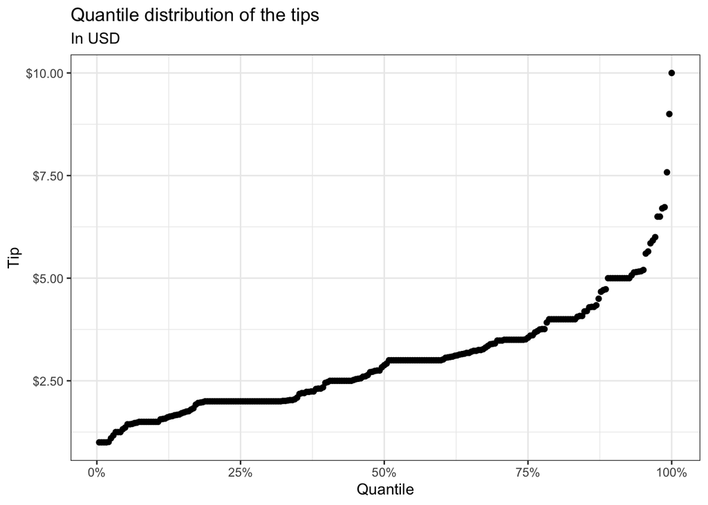

```r
df_tips |>
  mutate(
    rank = rank(tip, ties.method = "first"),
    f = rank/n()
  ) |>
  ggplot(aes(f, tip)) +
  geom_point() +
  scale_y_continuous(labels = scales::dollar) +
  scale_x_continuous(labels = scales::percent) +
  xlab("Quantile") + ylab("Tip") +
  ggtitle("Quantile distribution of the tips", "In USD") +
  theme_bw()
```

## Q1.3 Histogram of tips

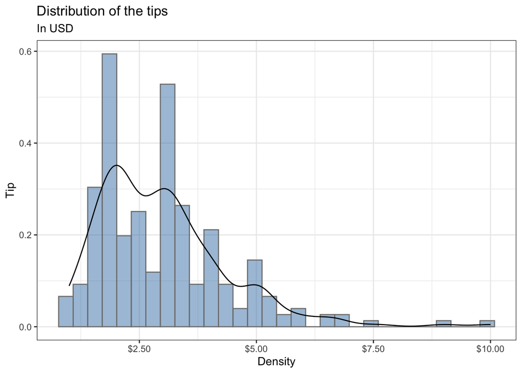

```r
df_tips |>
  ggplot(aes(tip)) +
  geom_histogram(aes(y=..density..), alpha = 0.5, fill = "steelblue", color = "gray50") +
  geom_density(color = "black") +
  scale_x_continuous(labels = scales::dollar) +
  xlab("Density") + ylab("Tip") +
  ggtitle("Distribution of the tips", "In USD") +
  theme_bw()
```

## Q1.4: Tip vs Total Bill

Extra: added a loess representation of the data.

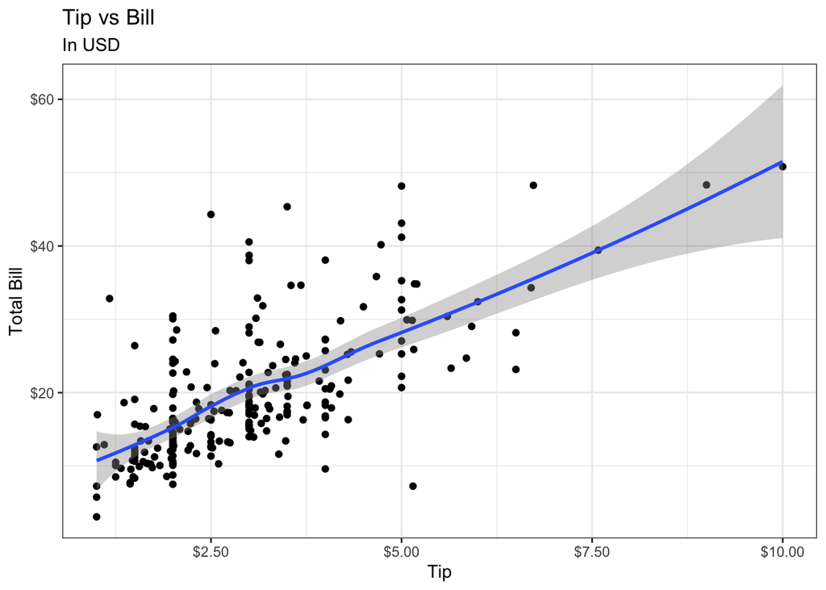

```r
df_tips |>
  ggplot(aes(tip, total_bill)) +
  geom_point() +
  geom_smooth() +
  xlab("Tip") + ylab("Total Bill") +
  scale_y_continuous(labels = scales::dollar) +
  scale_x_continuous(labels = scales::dollar) +
  ggtitle("Tip vs Bill", "In USD") +
  theme_bw()
```

Look if the tip as a percentage shows a different phenomena. Looks like a negative exponential phenomena (it will be studied furthermore in the following sections).

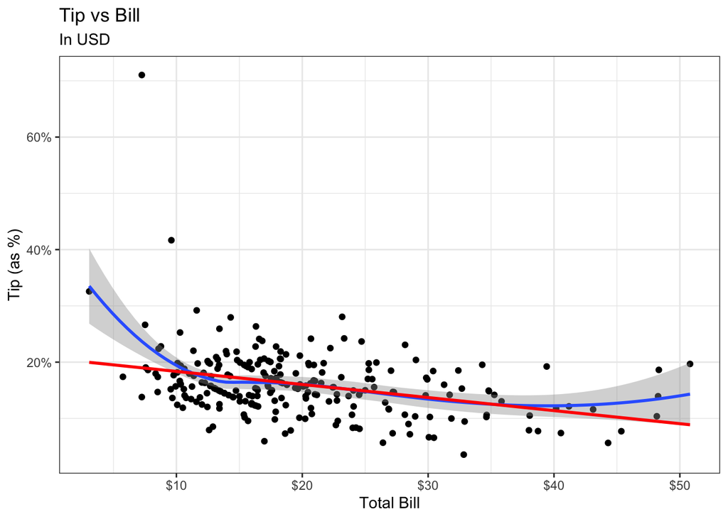

```r
df_tips |>
  ggplot(aes(total_bill, tip/total_bill)) +
  geom_point() +
  geom_smooth() +
  geom_smooth(method = "lm", color = 'red', se = FALSE) +
  scale_y_continuous(labels = scales::percent) +
  scale_x_continuous(labels = scales::dollar) +
  ggtitle("Tip vs Bill", "In USD") +
  xlab("Total Bill") + ylab("Tip (as %)") +
  theme_bw()
```

## Q1.5: Tip as a % of the total bill

```r
# get % of the bill as a tip
df_tips <- df_tips |>
  mutate(
    tip_percentage = tip/total_bill
  )

# get some quantiles
tibble(
  tip_percentage = quantile(df_tips$tip_percentage, p = 0:10/10),
  quantile = 0:10
)
```

| tip_percentage | quantile |
| --- | --- |
| 0.03563814 | 0 |
| 0.09855020 | 1 |
| 0.12127636 | 2 |
| 0.13723790 | 3 |
| 0.14664191 | 4 |
| 0.15476977 | 5 |
| 0.16657075 | 6 |
| 0.18194657 | 7 |
| 0.19707593 | 8 |
| 0.21726271 | 9 |

[output cut: 1 more lines]

## Q1.6: Histogram of the tip´

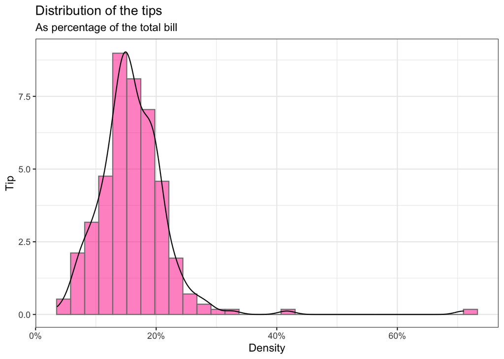

```r
df_tips |>
  ggplot(aes(tip_percentage)) +
  geom_histogram(aes(y=..density..), alpha = 0.5, fill = "deeppink", color = "gray50") +
  geom_density(color = "black") +
  scale_x_continuous(labels = scales::percent) +
  xlab("Density") + ylab("Tip") +
  ggtitle("Distribution of the tips", "As percentage of the total bill") +
  theme_bw()
```

Use some `bw` methods for the density with “solve the equation”. Use Sheather & Jones defualt method.

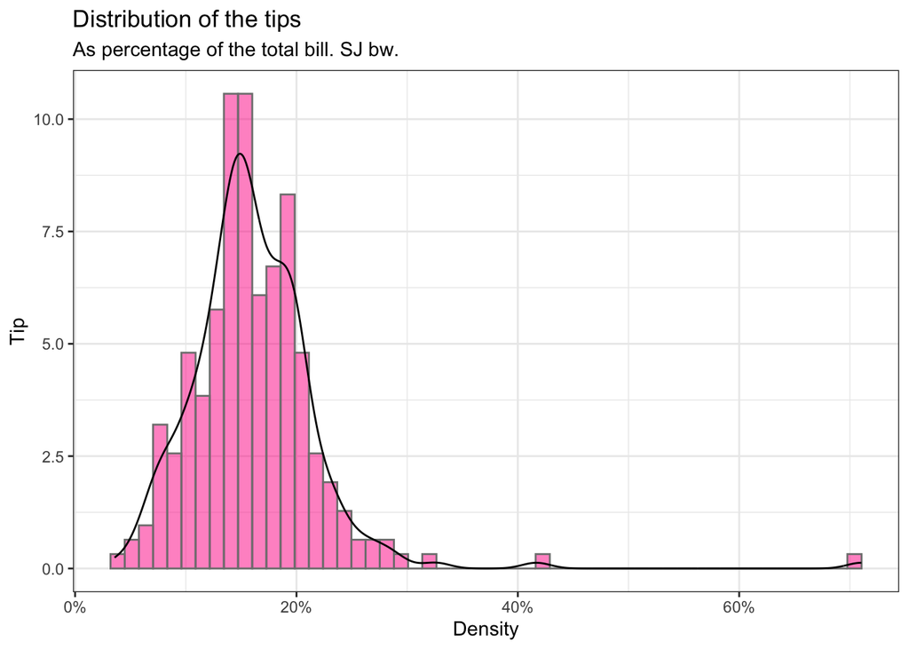

```r
tips_percent <- df_tips$tip_percentage

df_tips |>
  ggplot(aes(tip_percentage)) +
  geom_histogram(aes(y=..density..), alpha = 0.5, fill = "deeppink", color = "gray50", binwidth = bw.SJ(tips_percent)) +
  geom_density(color = "black", bw = "SJ") +
  scale_x_continuous(labels = scales::percent) +
  xlab("Density") + ylab("Tip") +
  ggtitle("Distribution of the tips", "As percentage of the total bill. SJ bw.") +
  theme_bw()
```

## Q1.7: Describe the tip as % of the bill

```r
# brief summary
df_tips |> pull(tip_percentage) |> summary()
```

```
##    Min. 1st Qu.  Median    Mean 3rd Qu.    Max.
## 0.03564 0.12913 0.15477 0.16080 0.19148 0.71034
```

```r
cat("\n")
```

```r
cat(df_tips |> pull(tip_percentage) |>  IQR())
```

```
## 0.06234812
```

```r
cat("\n")
```

```r
cat(df_tips |> pull(tip_percentage) |>  sd())
```

```
## 0.0610722
```

Lets look if there are some outliers

```r
# get tips as percentage
tips_percent <- df_tips$tip_percentage

# univariate analysis
lower_whisker <- quantile(tips_percent, 0.25) - 1.5 * IQR(tips_percent)
upper_whisker <- quantile(tips_percent, 0.75) + 1.5 * IQR(tips_percent)

# lower outlier
l_outlier <- tips_percent[tips_percent < lower_whisker]
u_outlier <- tips_percent[tips_percent > upper_whisker]
outliers <- cbind(l_outlier, u_outlier)

# look oultliers
cat(outliers |> sort())
```

```
## 0.2919897 0.3257329 0.4166667 0.7103448
```

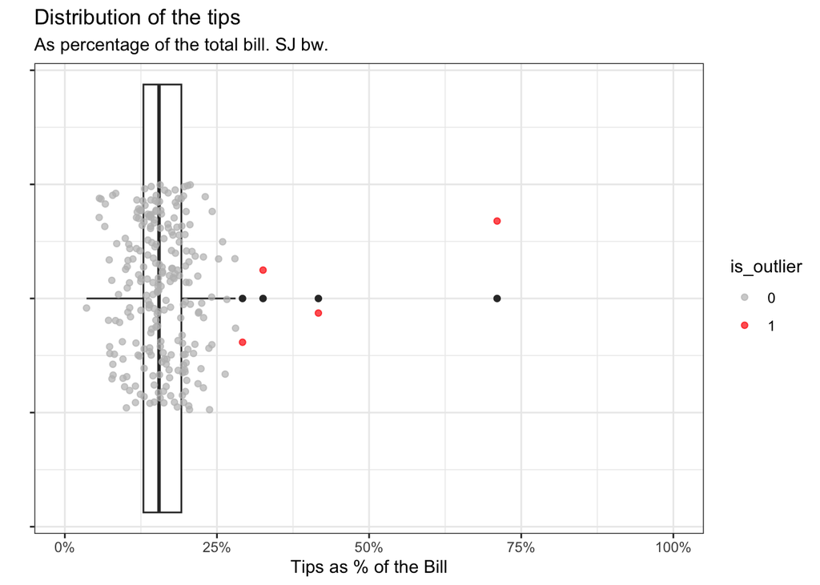

```r
# plot boxplot & cloud points
df_tips |>
  mutate(
    is_outlier = ifelse(tip_percentage > upper_whisker, 1, 0) |> as_factor()
  ) |>
  ggplot() +
  geom_boxplot(aes(tip_percentage)) +
  geom_jitter(aes(tip_percentage, 0, color = is_outlier), height = 0.2, width = 0, alpha = 0.7) +
  xlab("Tips as % of the Bill") + ylab("") +
  scale_x_continuous(labels = scales::percent, limits = c(0,1)) +
  scale_color_manual(breaks = c("0", "1"), values = c("gray", "red")) +
  ggtitle("Distribution of the tips", "As percentage of the total bill. SJ bw.") +
  theme_bw() +
  theme(
    axis.text.y = element_blank()
  )
```

Using a regression to look in a more robust way which data can have leverage.

```r
# fit an lm for the tips
fit_lm <- lm(
  data = df_tips,
  formula = "tip_percentage ~ . -tip"
)

# summary
summary(fit_lm)
```

```
##
## Call:
## lm(formula = "tip_percentage ~ . -tip", data = df_tips)
##
## Residuals:
##      Min       1Q   Median       3Q      Max
## -0.11497 -0.03339 -0.00477  0.02482  0.50056
##
## Coefficients:
##               Estimate Std. Error t value Pr(>|t|)
## (Intercept)  0.1877368  0.0279474   6.717 1.38e-10 ***
## total_bill  -0.0028208  0.0005393  -5.231 3.73e-07 ***
## sexMale     -0.0045720  0.0079538  -0.575    0.566
## smokerYes    0.0124607  0.0082332   1.513    0.132
## dayFri       0.0073073  0.0220960   0.331    0.741
## daySat       0.0042573  0.0264319   0.161    0.872
## daySun       0.0219716  0.0264933   0.829    0.408
## timeLunch    0.0068350  0.0249723   0.274    0.785
## size         0.0063183  0.0050284   1.257    0.210
## ---
## Signif. codes:  0 '***' 0.001 '**' 0.01 '*' 0.05 '.' 0.1 ' ' 1
##
## Residual standard error: 0.05753 on 235 degrees of freedom
## Multiple R-squared:  0.1419, Adjusted R-squared:  0.1127
## F-statistic: 4.859 on 8 and 235 DF,  p-value: 1.467e-05
```

Looks like only the total bill is a linear factor of the % of the tip. L Lets look for some confidence ellipses.

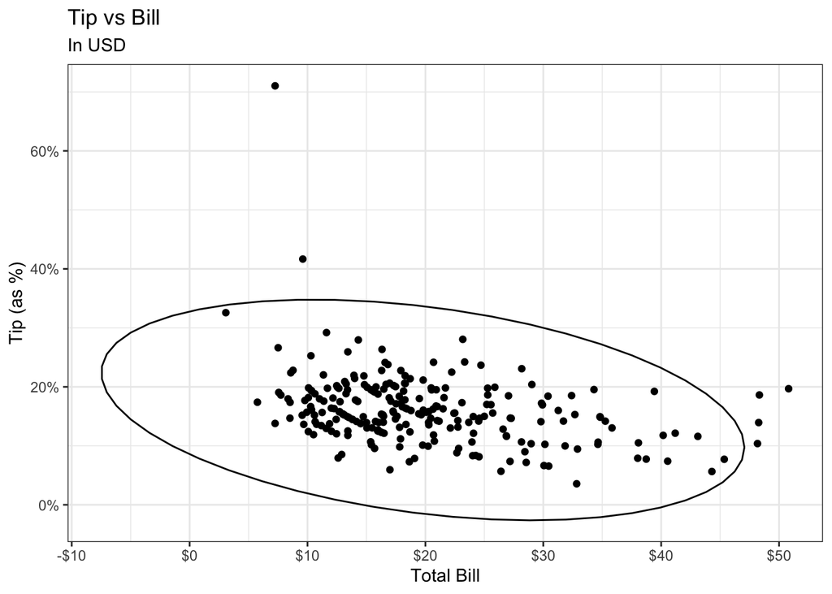

```r
df_tips |>
  ggplot(aes(total_bill, tip/total_bill)) +
  geom_point() +
  stat_ellipse(type = "norm", level = 0.99) +
  scale_y_continuous(labels = scales::percent) +
  scale_x_continuous(labels = scales::dollar) +
  ggtitle("Tip vs Bill", "In USD") +
  xlab("Total Bill") + ylab("Tip (as %)") +
  theme_bw()
```

At the end (not taking in account the “outliers” of the `total bill`), the 2 points of ~40% and ~70% as % of the bill look like outliers for the joint distribution.

## Q1.8 Outliers-Detector

As we saw, there are 2 possible outliers. Lets look them with more detail

```r
df_tips |>
  mutate(
    tip_percentage = tip/total_bill,
    is_outlier = ifelse(tip_percentage > upper_whisker, 1, 0) |> as_factor()
  ) |>
  filter(
    is_outlier == "1", tip_percentage > 0.4
  ) |>
  arrange(
    tip
  )
```

| total_bill | tip | sex | smoker | day | time | size | tip_percentage | is_outlier |
| --- | --- | --- | --- | --- | --- | --- | --- | --- |
| 9.60 | 4.00 | Female | Yes | Sun | Dinner | 2 | 0.4166667 | 1 |
| 7.25 | 5.15 | Male | Yes | Sun | Dinner | 2 | 0.7103448 | 1 |

It looks that it doesn’t matter if they are boys or girls for the outlier to happen. It is common in both that the day of the bill was on sunday, but this are reeeeally few observation, so we can’t conclude a lot (frequentist speaking).

## Q 1.9: Boxplot for tips

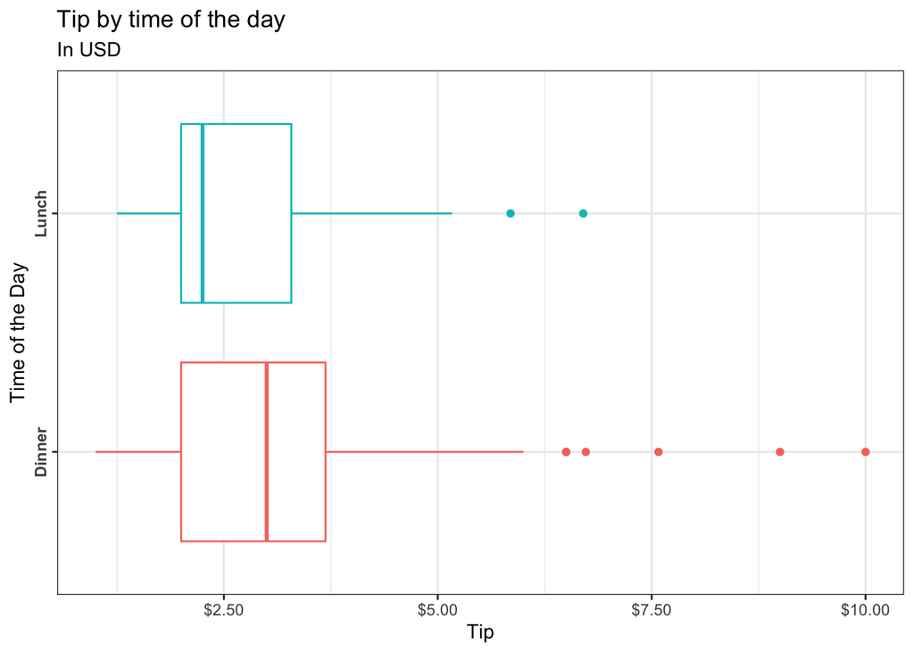

```r
# plot boxplot & cloud points
df_tips |>
  ggplot(aes(tip, time, color = time)) +
  geom_boxplot() +
  scale_x_continuous(labels = scales::dollar) +
  ggtitle("Tip by time of the day", "In USD") +
  xlab("Tip") + ylab("Time of the Day") +
  theme_bw() +
  theme(
    axis.text.y = element_text(angle = 90, hjust = 0.5, face = "bold"),
    legend.position = "None"
  )
```

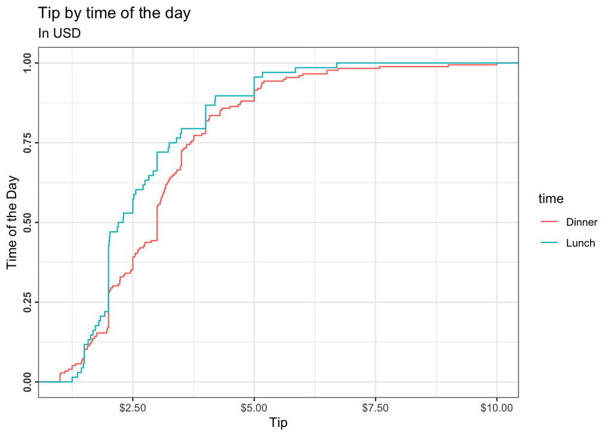

```r
# ecdf
df_tips |>
  ggplot(aes(tip, color = time)) +
  stat_ecdf() +
  scale_x_continuous(labels = scales::dollar) +
  ggtitle("Tip by time of the day", "In USD") +
  xlab("Tip") + ylab("Time of the Day") +
  theme_bw() +
  theme(
    axis.text.y = element_text(angle = 90, hjust = 0.5, face = "bold"),
  )
```

By the box plot & the ECD, it looks that the time of the day affects the total tip payed. To be sure this is not false, lets do a hypothesis test (a non parametric one, ’cause the tip can’t be normal distributed given the above data descriptions) if the dinner has a higher tip than in lunch.

```r
df_tips <- df_tips |>
  mutate(
    time = fct_relevel(time, c("Lunch", "Dinner"))
  )

wilcox.test(tip ~ time, data = df_tips, alternative = "less", conf.level = 0.95)
```

```
##
##  Wilcoxon rank sum test with continuity correction
##
## data:  tip by time
## W = 4905, p-value = 0.01441
## alternative hypothesis: true location shift is less than 0
```

It looks that there is evidence to think that the tips at lunch are lower that at dinner. But is this causal by itself or there can be an intermediate factor that affects this relationship? We looked that in the multinomial regression the tip as a % of the bill was not directly correlated to the time of the day but to the size itself of the bill.

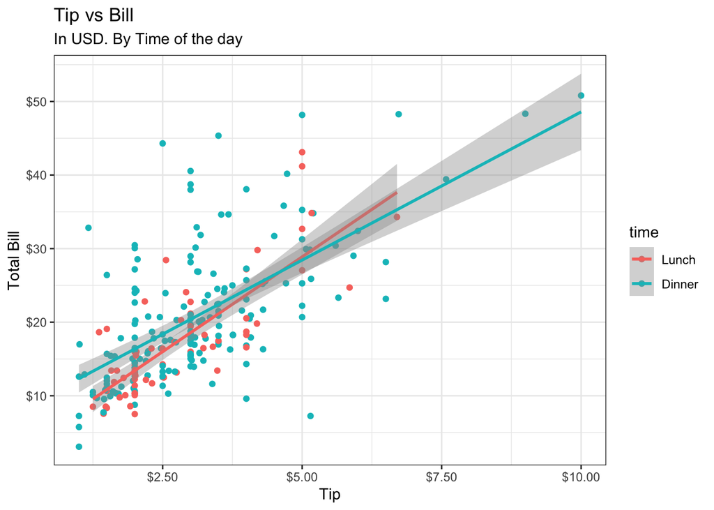

```r
df_tips |>
  ggplot(aes(tip, total_bill, color = time)) +
  geom_point() +
  geom_smooth(method = "lm") +
  xlab("Tip") + ylab("Total Bill") +
  scale_y_continuous(labels = scales::dollar) +
  scale_x_continuous(labels = scales::dollar) +
  ggtitle("Tip vs Bill", "In USD. By Time of the day") +
  theme_bw()
```

It clearly doesn’t look that the time of the day is determinant for the tip size but the size itself of the bill.

# Q2: Tea

```r
df_tea <- read_csv("data/tea.csv")
# look data
glimpse(df_tea)
```

```
## Rows: 300
## Columns: 36
## $ breakfast        <chr> "breakfast", "breakfast", "Not.breakfast", "Not.break…
## $ tea.time         <chr> "Not.tea time", "Not.tea time", "tea time", "Not.tea …
## $ evening          <chr> "Not.evening", "Not.evening", "evening", "Not.evening…
## $ lunch            <chr> "Not.lunch", "Not.lunch", "Not.lunch", "Not.lunch", "…
## $ dinner           <chr> "Not.dinner", "Not.dinner", "dinner", "dinner", "Not.…
## $ always           <chr> "Not.always", "Not.always", "Not.always", "Not.always…
## $ home             <chr> "home", "home", "home", "home", "home", "home", "home…
## $ work             <chr> "Not.work", "Not.work", "work", "Not.work", "Not.work…
## $ tearoom          <chr> "Not.tearoom", "Not.tearoom", "Not.tearoom", "Not.tea…
## $ friends          <chr> "Not.friends", "Not.friends", "friends", "Not.friends…
## $ resto            <chr> "Not.resto", "Not.resto", "resto", "Not.resto", "Not.…
## $ pub              <chr> "Not.pub", "Not.pub", "Not.pub", "Not.pub", "Not.pub"…
## $ Tea              <chr> "black", "black", "Earl Grey", "Earl Grey", "Earl Gre…
```

[output cut: 23 more lines]

## Q2.1: Create a cross-table with the type of sugar and tea

```r
df_tea |>
  count(Tea, sugar) |>
  pivot_wider(
    id_cols = Tea,
    names_from = sugar,
    values_from = n
  )
```

| Tea | No.sugar | sugar |
| --- | --- | --- |
| black | 51 | 23 |
| Earl Grey | 84 | 109 |
| green | 20 | 13 |

## Q2.2: Relationship of sugar & tea

It looks that the majority of the people tend to prefer no sugar for *black* and *green* tea, however for *earl grey* it looks that people prefer to add sugar to their teas.

```r
df_tea |>
  count(Tea, sugar) |>
  group_by(Tea) |>
  mutate(
    percent = n/sum(n)
  ) |>
  ungroup() |>
  pivot_wider(
    id_cols = Tea,
    names_from = sugar,
    values_from = percent
  )
```

| Tea | No.sugar | sugar |
| --- | --- | --- |
| black | 0.6891892 | 0.3108108 |
| Earl Grey | 0.4352332 | 0.5647668 |
| green | 0.6060606 | 0.3939394 |

## Q2.3: Cross table tea & how (presentation)

```r
df_tea |>
  count(Tea, how) |>
  pivot_wider(
    id_cols = how,
    names_from = Tea,
    values_from = n
  )
```

| how | black | Earl Grey | green |
| --- | --- | --- | --- |
| tea bag | 36 | 117 | 17 |
| tea bag+unpackaged | 23 | 60 | 11 |
| unpackaged | 15 | 16 | 5 |

## Q2.4: Percentage table tea & how (presentation)

```r
df_tea |>
  count(Tea, how) |>
  group_by(how) |>
  mutate(
    percent = n/sum(n)
  ) |>
  ungroup() |>
  pivot_wider(
    id_cols = how,
    names_from = Tea,
    values_from = percent
  )
```

| how | black | Earl Grey | green |
| --- | --- | --- | --- |
| tea bag | 0.2117647 | 0.6882353 | 0.1000000 |
| tea bag+unpackaged | 0.2446809 | 0.6382979 | 0.1170213 |
| unpackaged | 0.4166667 | 0.4444444 | 0.1388889 |

## Q2.5: Differences between tea drinkers regarding presentation

- By the above table, it looks that, given tea bag, people tend to prefer earl grey teas.
- For the unpacked tea bags drinkers, it looks they prefer earl grey teas.
- For unpacked, it looks that black and green tees are more prefered than in other presentations. But earl grey still dominating.

The earl gray domination in each presentation value can be dued to the fact that there are more observation of it than the other types of teas.

```r
df_tea |>
  count(Tea)
```

| Tea | n |
| --- | --- |
| black | 74 |
| Earl Grey | 193 |
| green | 33 |

```r
# v crammer test
cramerV(
  x = df_tea$Tea,
  y = df_tea$how
)
```

```
## Cramer V
##   0.1175
```

```r
# contgency table
df_tea |>
  count(Tea, how) |>
  rename(
    obs = n
  ) |>
  group_by(
    how
  ) |>
  mutate(
    n_how = sum(obs)
  ) |>
  ungroup() |>
  mutate(
    chisq_i = (obs - n_how * 1/3)^2 / (n_how * 1/3)
  ) |>
  pivot_wider(
    id_cols = how,
    names_from = Tea,
    values_from = chisq_i
  ) |>
  mutate(
    chisq = black + `Earl Grey` + green,
    p_chisq = pchisq(chisq, df = 3, lower.tail = FALSE)
  )
```

| how | black | Earl Grey | green | chisq | p_chisq |
| --- | --- | --- | --- | --- | --- |
| tea bag | 7.537255 | 64.237255 | 27.766667 | 99.541176 | 1.950512e-21 |
| tea bag+unpackaged | 2.216312 | 26.226950 | 13.195035 | 41.638298 | 4.787657e-09 |
| unpackaged | 0.750000 | 1.333333 | 4.083333 | 6.166667 | 1.037772e-01 |